# Synchrony_Dissertation_Process

Ester Kirby

2026-06-12

## Synchrony Dissertation Process

This is an RMarkdown serving as a data management plan and lab book for a dissertation undertaken in partial fulfillment of an MSc in Ecology, Evolution and Biodiversity (2026).

[output not shown]

```
## [1] 3594
```

```
## [1] 3588
```

```
## [1] 2019_EDI_1 2019_SER_3 2019_AVN_2 2019_MUN_1 2021_DOW_4 2021_AVN_8
## 3588 Levels: 2014_ALN_1 2014_ALN_2 2014_ALN_3 2014_ALN_4 ... 2025_TOM_8
```

```
## factor()
## 3588 Levels: 2014_ALN_1 2014_ALN_2 2014_ALN_3 2014_ALN_4 ... 2025_TOM_8
```

```
##
## Call:
## lm(formula = suc ~ clutch.swap.treatment, data = bludatswap)
##
## Residuals:
##     Min      1Q  Median      3Q     Max
## -6.5243 -1.5243  0.4757  2.4757  7.6939
##
## Coefficients:
##                           Estimate Std. Error t value Pr(>|t|)
## (Intercept)              4.259e-13  3.218e+00   0.000   1.0000
## clutch.swap.treatmentnot 5.810e+00  3.294e+00   1.764   0.0783 .
## clutch.swap.treatmentodd 4.306e+00  3.251e+00   1.325   0.1858
## clutch.swap.treatmentswa 6.524e+00  3.224e+00   2.024   0.0435 *
## clutch.swap.treatmentunm 6.081e+00  3.224e+00   1.886   0.0598 .
## ---
## Signif. codes:  0 '***' 0.001 '**' 0.01 '*' 0.05 '.' 0.1 ' ' 1
##
## Residual standard error: 3.218 on 593 degrees of freedom
##   (16 observations deleted due to missingness)
## Multiple R-squared:  0.03832,    Adjusted R-squared:  0.03183
## F-statistic: 5.907 on 4 and 593 DF,  p-value: 0.000115
```

```
## Linear mixed model fit by REML ['lmerMod']
## Formula: suc ~ clutch.swap.treatment + (1 | site) + (1 | year)
##    Data: bludatswap
##
## REML criterion at convergence: 2995.8
##
## Scaled residuals:
##     Min      1Q  Median      3Q     Max
## -2.9250 -0.4790  0.1282  0.6577  2.8898
##
## Random effects:
##  Groups   Name        Variance Std.Dev.
##  site     (Intercept) 1.7996   1.3415
##  year     (Intercept) 0.9725   0.9861
##  Residual             7.9721   2.8235
## Number of obs: 598, groups:  site, 44; year, 3
##
## Fixed effects:
##                          Estimate Std. Error t value
## (Intercept)               -0.7089     2.9500  -0.240
## clutch.swap.treatmentnot   6.2034     2.9618   2.094
## clutch.swap.treatmentodd   4.8789     2.9194   1.671
## clutch.swap.treatmentswa   6.9869     2.8900   2.418
## clutch.swap.treatmentunm   6.7575     2.8927   2.336
##
## Correlation of Fixed Effects:
##                    (Intr) cltch.swp.trtmntnt cltch.swp.trtmntd
## cltch.swp.trtmntnt -0.955
## cltch.swp.trtmntd  -0.968  0.965
## cltch.swp.trtmnts  -0.977  0.974              0.988
## cltch.swp.trtmntnm -0.977  0.974              0.987
##                    cltch.swp.trtmnts
## cltch.swp.trtmntnt
## cltch.swp.trtmntd
## cltch.swp.trtmnts
## cltch.swp.trtmntnm  0.996
```

```
## 'data.frame':    614 obs. of  52 variables:
##  $ year                            : int  2017 2017 2017 2017 2017 2017 2017 2017 2017 2017 ...
##  $ site                            : chr  "EDI" "EDI" "EDI" "EDI" ...
##  $ box                             : int  1 2 3 4 5 6 7 8 1 2 ...
##  $ predator_proof                  : chr  "" "" "" "" ...
##  $ species                         : chr  "bluti" "bluti" "bluti" "bluti" ...
##  $ visit.frequency                 : chr  "" "" "" "" ...
##  $ moss                            : chr  "" "" "" "" ...
##  $ n1                              : chr  "111" "91" "93" "93" ...
##  $ nl                              : chr  "119" "97" "101" "113" ...
##  $ latestfed                       : int  NA NA NA NA NA NA NA NA NA NA ...
##  $ latestcc                        : int  NA NA NA NA NA NA NA NA NA NA ...
##  $ fed                             : int  121 106 114 121 115 113 112 110 114 121 ...
##  $ cc                              : chr  "130" "114" "125" "129" ...
##  $ cs                              : int  10 9 10 9 9 6 8 10 9 9 ...
```

[output cut: 38 more lines]

```
## Linear mixed model fit by REML ['lmerMod']
## Formula: suc ~ (1 | clutch.swap.treatment) + year + (1 | site)
##    Data: bludatswap
##
## REML criterion at convergence: 11024.8
##
## Scaled residuals:
##     Min      1Q  Median      3Q     Max
## -2.5228 -0.6959  0.1815  0.7443  2.7491
##
## Random effects:
##  Groups                Name        Variance Std.Dev.
##  site                  (Intercept) 0.9537   0.9766
##  clutch.swap.treatment (Intercept) 0.6454   0.8033
##  Residual                          9.4353   3.0717
## Number of obs: 2150, groups:  site, 44; clutch.swap.treatment, 14
##
## Fixed effects:
##             Estimate Std. Error t value
## (Intercept) 60.90904   45.56427   1.337
## year        -0.02722    0.02257  -1.206
##
## Correlation of Fixed Effects:
##      (Intr)
## year -1.000
```

```
##
##                                                                       1614
##                                                                          1
##                                                                         36
##                                                                          2
##                                                                         31
##                                                                          3
##                                                                         42
##                                                                          4
##                                                                         42
##                                                                          5
##                                                                         29
##                                                                          6
##                                                                         36
##                                                                          7
##                                                                         19
##                                                                          8
##                                                                         34
##                                                               not possible
##                                                                         22
##                                                                        odd
##                                                                         52
## odd - incorrect CC first noted as 123, therefore not checked for many days
##                                                                          1
##                                                                       odd?
##                                                                          1
##                                                              unmanipulated
##                                                                        266
```

```
##
##                                                                   5.003863
##                                                                          1
##                                                                   7.555556
##                                                                          2
##                                                                   6.290323
##                                                                          3
##                                                                   5.642857
##                                                                          4
##                                                                   6.095238
##                                                                          5
##                                                                   6.250000
##                                                                          6
##                                                                   6.333333
##                                                                          7
##                                                                   7.894737
##                                                                          8
##                                                                   6.939394
##                                                               not possible
##                                                                   5.809524
##                                                                        odd
##                                                                   4.212766
## odd - incorrect CC first noted as 123, therefore not checked for many days
##                                                                   8.000000
##                                                                       odd?
##                                                                   5.000000
##                                                              unmanipulated
##                                                                   6.080769
```

Above, I isolated the clutch swap experiment years and ran a linear mixed model to look for variance attributed to clutch swap treatment as opposed to unmanipulated clutches. This allowed me to decide whether to include these years, just the unmanipulated broods, or exclude entirely. Overall variance attributed to treatment was low compared to residual, and mean success was similar between unmanipulated and swapped clutches. Therefore, it appears the effect of the clutch swap experiment on fledgling success was negligible and these years can be included in full.

```
## Linear mixed model fit by REML ['lmerMod']
## Formula: suc ~ (1 | year) + (1 | site) + (1 | site_year)
##    Data: bludat
##
## REML criterion at convergence: 10785.6
##
## Scaled residuals:
##     Min      1Q  Median      3Q     Max
## -2.6978 -0.6260  0.1554  0.7190  3.2470
##
## Random effects:
##  Groups    Name        Variance Std.Dev.
##  site_year (Intercept) 0.5801   0.7616
##  site      (Intercept) 0.9118   0.9549
##  year      (Intercept) 1.5525   1.2460
##  Residual              7.9000   2.8107
## Number of obs: 2150, groups:  site_year, 485; site, 44; year, 12
##
## Fixed effects:
##             Estimate Std. Error t value
## (Intercept)    5.288      0.395   13.39
```

```
## var.intercept.site_year      var.intercept.site      var.intercept.year
##               0.5800666               0.9117588               1.5525096
```

```
## (Intercept)
##   0.7279973
```

Here, I ran a simple linear mixed model on fledgling success with year, site and site year random effects. I then extracted the variance components and calculated the ICC of fledgling success synchrony

```
##         [,1] [,2] [,3] [,4] [,5] [,6] [,7] [,8] [,9]
## y_site1   32   42   64   85   82   78   73   69   79
## y_site2   22   24   40   54   51   46   51   41   58
## y_site3   38   42   72  108   88   91   92   82   87
```

```
##         [,1] [,2] [,3] [,4] [,5] [,6] [,7] [,8]
## J_site1  189  274  398  538  520  476  463  438
## J_site2  113  187  300  281  303  282  296  255
## J_site3  180  408  425  619  713  611  712  627
```

```
##         [,1] [,2] [,3] [,4] [,5] [,6] [,7] [,8]
## R_site1   28   36   57   77   81   83   77   72
## R_site2   13   17   39   45   41   49   52   52
## R_site3   28   44   63   91  106   95   92   93
```

```
## Inference for Stan model: anon_model.
## 3 chains, each with iter=20000; warmup=10000; thin=5;
## post-warmup draws per chain=2000, total post-warmup draws=6000.
##
##                    mean se_mean    sd  2.5%   25%   50%   75% 97.5% n_eff  Rhat
## mphij             0.123   0.000 0.030 0.074 0.107 0.120 0.134 0.188  5706 1.000
## mphia             0.415   0.001 0.038 0.346 0.398 0.414 0.431 0.487  4736 1.000
## mfec              6.867   0.017 0.893 5.207 6.493 6.830 7.191 8.676  2684 1.000
## mim               0.240   0.002 0.114 0.088 0.181 0.226 0.276 0.483  5403 1.000
## sig_phij          0.315   0.002 0.117 0.161 0.237 0.291 0.365 0.613  5615 1.000
## sig_phia          0.192   0.001 0.103 0.036 0.124 0.175 0.241 0.439  5554 1.000
## sig_fec           0.142   0.001 0.070 0.031 0.097 0.132 0.173 0.312  4814 1.000
## sig_im            0.407   0.005 0.304 0.018 0.175 0.347 0.567 1.139  3419 1.000
## sig_site_phij     0.304   0.004 0.277 0.044 0.129 0.214 0.376 1.092  5586 1.000
## sig_site_phia     0.133   0.003 0.198 0.003 0.029 0.070 0.149 0.708  4244 1.000
## sig_site_fec      0.118   0.003 0.168 0.003 0.027 0.062 0.133 0.618  3334 1.001
## sig_site_im       0.401   0.006 0.376 0.013 0.134 0.289 0.549 1.453  4255 1.000
## sig_sy_phij       0.039   0.000 0.031 0.002 0.015 0.032 0.055 0.116  6170 1.000
## sig_sy_phia       0.048   0.001 0.038 0.002 0.019 0.039 0.068 0.141  5375 1.000
## sig_sy_fec        0.118   0.000 0.031 0.069 0.096 0.113 0.135 0.191  4934 1.000
## sig_sy_im         0.207   0.002 0.161 0.008 0.082 0.170 0.296 0.600  4825 1.000
## mlam[1]           1.093   0.000 0.023 1.048 1.078 1.093 1.109 1.140  6073 1.000
## mlam[2]           1.100   0.000 0.029 1.045 1.080 1.099 1.119 1.158  5886 1.000
## mlam[3]           1.099   0.000 0.022 1.057 1.083 1.099 1.113 1.145  5794 1.000
## var_phij_year     0.113   0.001 0.102 0.026 0.056 0.085 0.134 0.376  5689 1.000
## var_phij_siteyear 0.002   0.000 0.004 0.000 0.000 0.001 0.003 0.014  6127 1.000
## icc_phij          0.969   0.001 0.054 0.812 0.964 0.990 0.998 1.000  6077 1.000
## var_phia_year     0.047   0.001 0.063 0.001 0.015 0.031 0.058 0.193  6033 1.000
## var_phia_siteyear 0.004   0.000 0.006 0.000 0.000 0.002 0.005 0.020  5232 1.000
## icc_phia          0.868   0.003 0.201 0.216 0.838 0.957 0.991 1.000  4827 1.001
## var_fec_year      0.025   0.000 0.030 0.001 0.009 0.017 0.030 0.098  5348 1.000
## var_fec_siteyear  0.015   0.000 0.008 0.005 0.009 0.013 0.018 0.036  4866 1.000
## icc_fec           0.552   0.003 0.234 0.032 0.397 0.587 0.734 0.913  4587 1.000
## var_im_year       0.258   0.006 0.387 0.000 0.031 0.120 0.322 1.298  3796 1.000
## var_im_siteyear   0.069   0.001 0.104 0.000 0.007 0.029 0.087 0.360  4914 1.000
## icc_im            0.671   0.005 0.331 0.007 0.411 0.806 0.962 1.000  4739 1.000
##
## Samples were drawn using NUTS(diag_e) at Sat Jun 13 14:06:51 2026.
## For each parameter, n_eff is a crude measure of effective sample size,
## and Rhat is the potential scale reduction factor on split chains (at
## convergence, Rhat=1).
```

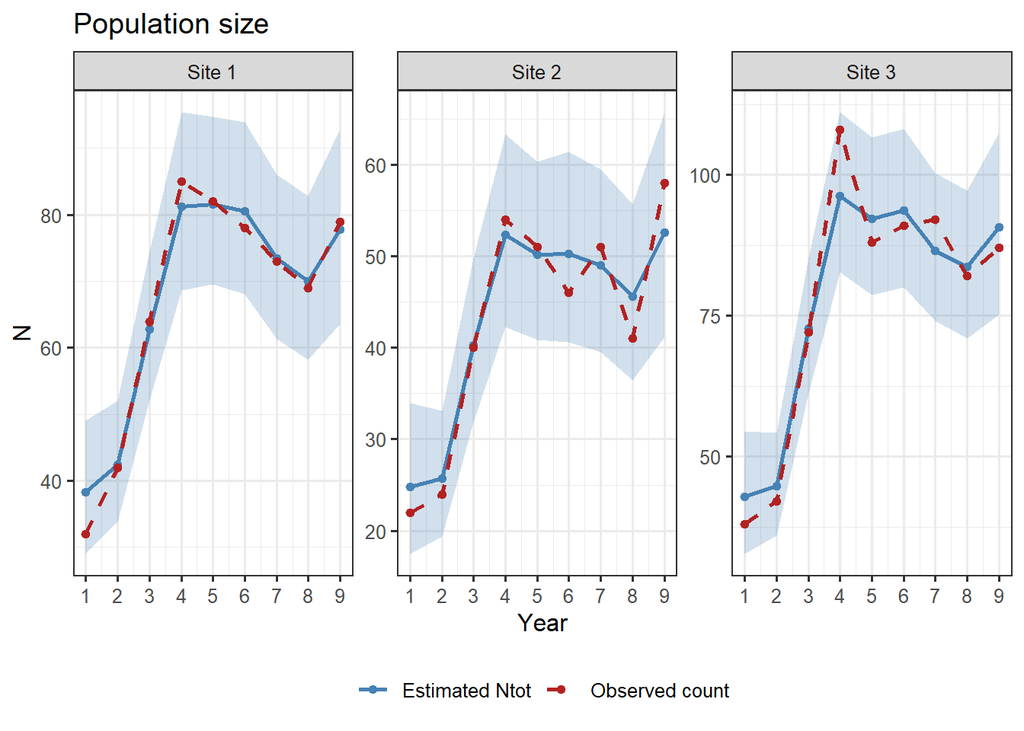

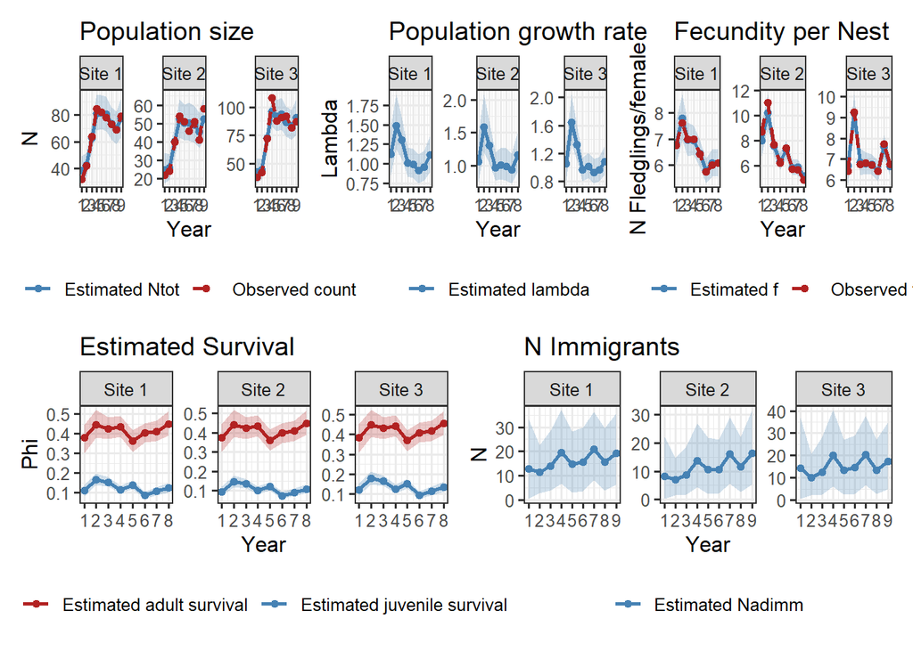

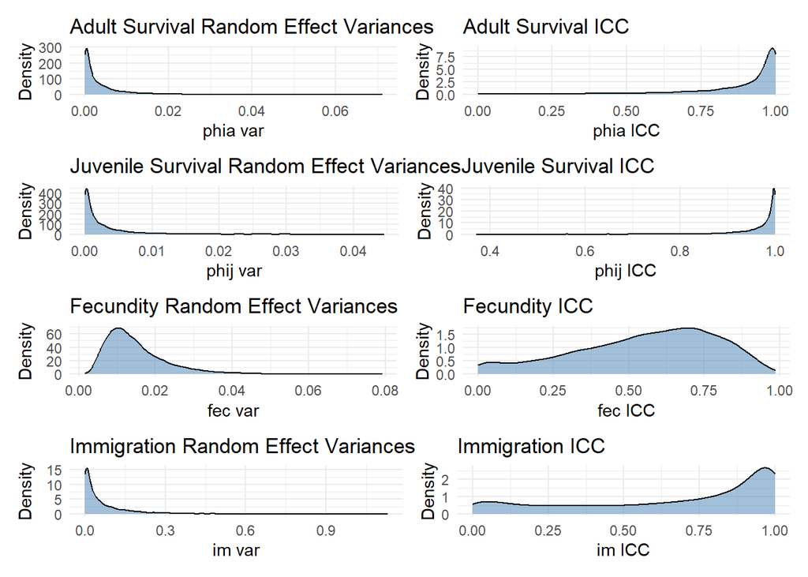

```
##       2015 2016 2017 2018 2019 2020 2021 2022 2023 2024 2025
##  [1,]    1    0    0    0    0    0    0    0    0    0    0
##  [2,]    1    0    0    0    0    0    0    0    0    0    0
##  [3,]    1    1    0    0    0    0    0    0    0    0    0
##  [4,]    1    0    0    0    0    0    0    0    0    0    0
##  [5,]    1    0    0    0    0    0    0    0    0    0    0
##  [6,]    1    0    1    1    0    0    0    0    0    0    0
##  [7,]    0    1    0    0    0    0    0    0    0    0    0
##  [8,]    0    1    0    0    0    0    0    0    0    0    0
##  [9,]    0    1    0    0    0    0    0    0    0    0    0
## [10,]    0    0    1    1    1    0    0    0    0    0    0
## [11,]    0    0    1    0    1    1    0    0    0    0    0
## [12,]    0    0    1    0    0    0    0    0    0    0    0
## [13,]    0    0    1    1    1    1    0    0    0    0    0
## [14,]    0    0    0    1    0    0    0    0    0    0    0
```

[output cut: 31 more lines]

```
##       [,1] [,2] [,3] [,4] [,5] [,6] [,7] [,8] [,9] [,10] [,11]
##  [1,]    1    1    0    0    0    0    0    0    0     0     4
##  [2,]    0    0    0    0    0    0    0    0    0     0     4
##  [3,]    0    0    3    1    0    0    0    0    0     0     1
##  [4,]    0    0    0    3    0    0    0    0    0     0     7
##  [5,]    0    0    0    0    5    0    0    0    0     0     3
##  [6,]    0    0    0    0    0    5    0    1    0     0     4
##  [7,]    0    0    0    0    0    0    2    0    0     0     8
##  [8,]    0    0    0    0    0    0    0    1    0     0     2
##  [9,]    0    0    0    0    0    0    0    0    1     1     4
## [10,]    0    0    0    0    0    0    0    0    0     3     2
```

The M-array above, generated from capture histories above the m-array using Kery and Schaub’s marray function, shows individual capture histories at site ‘ALN’ collapsed into, on the diagonal, individuals marked and released on the nth occasion and recaptured on the n+1th occasion. The next column over on the same row shows individuals released on the nth occasion and recaptured on the n+2nd occasion. The far right column represents individuals marked and never recaptured. This is the format the IPM will take for the CMR portion of the model to estimate apparent survival.

##Plotting IPM inputs

The IPM takes population size data - in the form of maximum occupancy - as y_mat, the number of successful fledglings at each site each year - as J_mat, and the number of broods surveyed at each site in each year - as R_mat. These are plotted below:

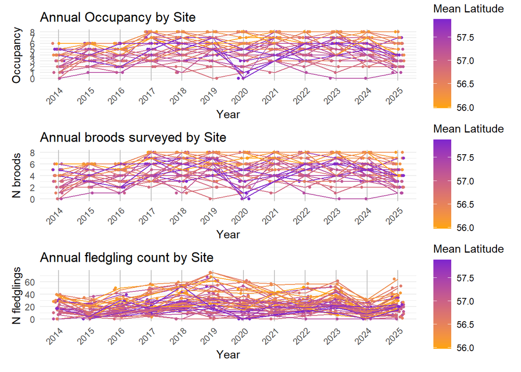

##IPM data formatting

In the meantime, I’m working my way through the Rstan hoopoe IPM to see where I need to alter it for the blue tit data. I’ve removed all lines relating to phij as I have not looked at fledgling survival yet. I’m now trying to parse what each chunk is doing so that I can identify where nyears - 1 needs to be changed to nyears (the hoopoe data takes nyears-1 for # of fledglings and also # of broods surveyed, while we have data for these:

```r
#blue tit data format
print(dim(y_mat_bt))
```

```
## [1] 44 12
```

```r
print(dim(J_mat_bt))
```

```
## [1] 44 12
```

```r
print(dim(R_mat_bt))
```

```
## [1] 44 12
```

```r
print(dim(marray_list))
```

```r
print("this returns NULL but is a list of 44 m-arrays containing up to 12 years of releases and 11 years of recaptures (n years by n-1 years)")
```

```
## [1] "this returns NULL but is a list of 44 m-arrays containing up to 12 years of releases and 11 years of recaptures (n years by n-1 years)"
```

```r
#Whereas for the hoopoes - which is the format taken by the RStan code
print(dim(y_mat))
```

```
## [1] 3 9
```

```r
print(dim(J_mat))
```

```
## [1] 3 8
```

```r
print(dim(R_mat))
```

```
## [1] 3 8
```

```r
print(dim(marray_j_3d))
```

```
## [1] 3 8 9
```

```r
print(dim(marray_a_3d))
```

```
## [1] 3 8 9
```

As we can see above, J_mat and R_mat take dimensions (site, nyear-1) in the hoopoe model, whereas for the blue tit data they take (site, nyear). However, for the M-arrays, both Hoopoe and blue tit take (site, nyear-1, nyear). Therefore, some nyear-1s in the stan file need editing to nyear while others need leaving.

Following Sanjana’s email, I now understand that my data should be formatted the same as the Hoopoe data. This is because the nestling counts and surveyed broods do not exist at t=1, but somewhere between t=t and t=t+1. Therefore, the 12th entry should not exist from the model’s perspective as the 12th year is still pre breeding - and from the model perspective, is until the 13th year. I have removed the 12th year below, as well as reformatting each input as.integer:

```
## [1] 44 12
```

```
## [1] 44 11
```

```
## [1] 44 11
```

```
## [1] 44 11 12
```

Next, I have repurposed the hoopoe code for the blue tits to fit the model. However, the following is causing issues:

” N1 = lapply(1:nsites, function(s) round(runif(nyears, 1, 50))), NadSurv = lapply(1:nsites, function(s) round(runif(nyears, 5, 50))), Nadimm = lapply(1:nsites, function(s) round(runif(nyears, 1, 50)))”

I think this is because some sites have very low occupancy, which is where we draw our Ntot estimate. This then pulls the estimate down towards 0, making it very easy for the number of adults surviving to the next census to exceed the number of adults. This is, naturally, impossible. To fix this maybe we add a parameter similar to recapture probability? That can vary site to site? That tells us that occupancy is in some way proportional to Ntot but not representative.

I’m also worrying a bit about sites and boxes that weren’t added until later years - I think they’re being included in the model as empty rather than absent for the years before their implementation. This would create an artificial spike in lambda/ntot from 2016-2017 for example. I’m not sure how this would resolve as the model seems pretty inflexible on NAs and the dimensions of input data.